# SB827/GTFSr Examples

Tom Buckley

3/3/2018

## Senate Bill 827

The intent of Senate Bill 827 is to allow for more housing in areas of California with good transit.

## “Transit-Rich”

Lets look at a specific recent amendment to the bill to understand how good is defined.

## Within a 1/4 mile of a High Frequency Transit Stop

A recently proposed amendment to Senate Bill 827 says:

“A project must be within ¼ mile of a transit *stop* on a high frequency transit corridor to trigger SB 827.”

https://leginfo.legislature.ca.gov/faces/billTextClient.xhtml?bill_id=201720180SB827

So we’ll need to be able to identify a few things in order to say whether a project triggers 827.

1. transit stops
2. transit corridors
3. high frequency transit corridors

All of these have an intuitive definition, but we have to make assumptions in order to identify them.

## SB 827 Features

So lets try to find the [features](https://r-spatial.github.io/sf/articles/sf1.html#what-is-a-feature) in the world that correspond to (1), (2), and (3).

### R Studio/GTFSr

I’m going to use [R Studio](https://www.rstudio.com/) to get [GTFS Transit Data](https://en.wikipedia.org/wiki/General_Transit_Feed_Specification) and put it in maps and tables corresponding to (1), (2) and (3).

GTFS characterizes stops, routes, and schedules, among other things.

The top of this example is drawn from the [introductory documents](https://github.com/ropensci/gtfsr).

### Getting Transit Data

#### TransitFeeds

TransitFeeds is a community edited site that lists transit data for tens of thousands of places around the world. Its awesome.

There’s an excellent introduction to pulling data for any city in TransitFeeds in the gtfsr documents [here](https://ropensci.github.io/gtfsr/articles/gtfsr-vignette.html#get-an-gtfs-api-key).

#### MTC 511

I found that, for the Bay Area, it made more sense to use MTC’s 511 API.

Among other reasons, their list of operators is more comprehensive (see appendix).

```r
library(readr)

#read 511 orgs list
o511 <- read_csv("https://gist.githubusercontent.com/tibbl35/d49fa2c220733b0072fc7c59e0ac412b/raw/cff45d8c8dd2ea951b83c0be729abe72f35b13f7/511_orgs.csv")
o511 <- o511[,c("Name","PrivateCode","PrimaryMode")]

knitr::kable(o511)
```

| Name | PrivateCode | PrimaryMode |
| --- | --- | --- |
| AC Transit | AC | bus |
| Alcatraz Hornblower Ferry | HF | ferry |
| Altamont Corridor Express | CE | rail |
| American Canyon Transit | AY | bus |
| Angel Island Tiburon Ferry | AT | ferry |
| BART | BA | rail |
| Blue & Gold Fleet | BG | ferry |
| Caltrain | CT | rail |
| Capitol Corridor | AM | rail |
| Commute.org | CM | bus |
| County Connection | CC | bus |
| Dumbarton Express | DE | bus |
| Emery Go-Round | EM | bus |
| Fairfield and Suisun Transit (FAST) | FS | bus |
| Golden Gate Ferry | GF | ferry |
| Golden Gate Transit | GG | bus |
| Marin Transit | MA | bus |
| Petaluma Transit | PE | bus |
| Rio Vista Delta Breeze | RV | bus |
| SamTrans | SM | bus |
| San Francisco Bay Ferry | SB | ferry |
| Santa Rosa CityBus | SR | bus |
| SFMTA | SF | bus |
| SMART | SA | rail |
| Soltrans | ST | bus |
| Sonoma County Transit | SO | bus |
| Stanford Marguerite Shuttle | MS | bus |
| Tri Delta Transit | 3D | bus |
| Union City Transit | UC | bus |
| Vacaville City Coach | VC | bus |
| Vine (Napa County) | VN | bus |
| VTA | SC | bus |
| WestCAT | WC | bus |
| Wheels | WH | bus |

We’ll use the “PrivateCode” to get data for a given operator.

I’m going to use a list of URL’s that I got from [MTC 511](http://511.org/developers/list/apis/).

So, lets get San Francisco’s transit data.

Note that you’ll need an MTC511 API Key. You can get one [here](http://511.org/developers/list/apis/)

```r
library(dplyr)
operator_acronym <- filter(o511, Name == "SFMTA") %>% select(PrivateCode)

#Sys.setenv(APIKEY511 = "YOUR API KEY")
api_key = Sys.getenv("APIKEY511")

zip_request_url = paste0('http://api.511.org/transit/datafeeds?api_key=',
                           api_key,
                           '&operator_id=',
                           operator_acronym)

g1 <- zip_request_url %>% import_gtfs
```

```
## Unzipped the following files to directory '/private/var/folders/hk/12t7fl6d08s7r494zd9sb8v40000gn/T/Rtmpxl3k6t/file10924c86f4ef'...
```

```
##  [1] "agency.txt"                "calendar_attributes.txt"
##  [3] "calendar_dates.txt"        "calendar.txt"
##  [5] "directions.txt"            "fare_attributes.txt"
##  [7] "fare_rider_categories.txt" "fare_rules.txt"
##  [9] "feed_info.txt"             "rider_categories.txt"
## [11] "routes.txt"                "shapes.txt"
## [13] "stop_times.txt"            "stops.txt"
## [15] "trips.txt"
```

[output not shown]

[output not shown]

[output not shown]

[output not shown]

[output not shown]

[output not shown]

[output not shown]

[output not shown]

[output not shown]

[output not shown]

[output not shown]

[output not shown]

[output not shown]

[output not shown]

[output not shown]

```
## ...done.
```

```
## Testing data structure...
```

```
## ...passed. Valid GTFS object.
```

```
## NOTE: Parsing errors and warnings while importing data can be extracted from any given dataframe with `attr(df, "problems")`.
```

### (1) Transit Stops

This should be easy. A stop is discrete.

```r
dim(g1$stops_df)[1]
```

```
## [1] 3536
```

Here we see there are 3k stops in SF Muni.

Lets look at a random sample of stops.

```r
some_stops <- g1$stops_df[sample(nrow(g1$stops_df), 40),]

some_stops_sf <- stops_df_as_sf(some_stops)

mapview(some_stops_sf)
```

[interactive chart not shown]

OK so seems like we’ve got (1).

What about (2)?

### Transit Corridors

Since we’ve already identified some stops, lets get the routes those stops are on.

So how do we figure out which routes these stops are on?

We have to wade into the GTFS data model a bit to answer that question.

Thankfully, Danny Whalen made a chart which clarifies the data model:

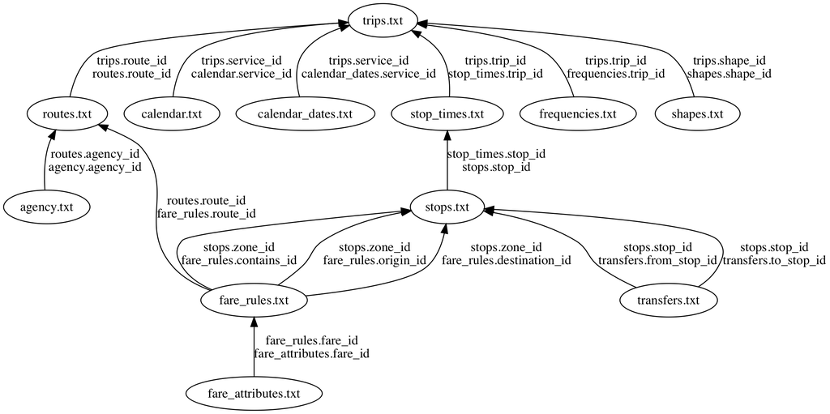

So lets apply some dplyr verbs to get the routes for these stops.

```r
some_stop_times <- g1$stop_times_df %>%
    filter(stop_id %in% some_stops$stop_id)

some_trips <- g1$trips_df %>%
  filter(trip_id %in% some_stop_times$trip_id)

some_routes <- g1$routes_df %>%
  filter(route_id %in% some_trips$route_id)
```

Lets map these routes.

```r
rts_sf <- gtfsr::routes_df_as_sf(g1)

some_routes_sf <- rts_sf %>%
  filter(route_id %in% some_trips$route_id)

#in order to get mapview to display the routes
#had to save the data to a tempfile and read it back
tempfile1 <- tempfile("some_routes", fileext = ".gpkg")
st_write(some_routes_sf,tempfile1)
```

```
## Writing layer `some_routes10924442081e' to data source `/var/folders/hk/12t7fl6d08s7r494zd9sb8v40000gn/T//Rtmpxl3k6t/some_routes10924442081e.gpkg' using driver `GPKG'
## features:       42
## fields:         1
## geometry type:  Multi Line String
```

```r
some_routes_sf <- st_read(tempfile1)
```

```r
mapview(some_routes_sf)
```

[interactive chart not shown]

### High Frequency

The next question is: how do we calculate frequency?

First, we also need to identify which calendar we are intersted in. In our case, weekdays.

```r
c1 <- g1$calendar_attributes_df

weekday_service_id <- c1[c1$service_description=="Weekday",]$service_id
```

Lets try focusing on just 1 stop to see how this works.

```r
a_stop_id <- some_stops_sf[1,]$stop_id
```

```r
stop_ids <- some_stops_sf[1:10,]$stop_id
#
# headways <- sapply(stop_ids, function(x) stop_headway(x,g1$stop_times_df,
#                                                           g1$trips_df,
#                                                           weekday_service_id))
```

Lets try filtering for specific times of day.

```r
stop_times_dt <- stop_times_df_as_dt(g1$stop_times_df)
```

```r
library(lubridate)
am_start <- hms("06:00:00")
am_end <- hms("09:59:00")
pm_start <- hms("15:00:00")
pm_end <- hms("18:59:00")

peak_stop_times <- (stop_times_dt$departure_time > am_start &
                    stop_times_dt$departure_time < am_end) |
                    (stop_times_dt$departure_time > pm_start &
                    stop_times_dt$departure_time < pm_end)

#filter the df not dt frame here b/c of
#bug where stop_times_dt$departure_times was not being filtered
stop_times_df <- g1$stop_times_df[peak_stop_times,]
stop_ids <- unique(stop_times_df$stop_id)
```

## Appendix

### MTC 511 API has more Operator coverage than TransitFeed

Compare coverage tables:

```r
library(gtfsr)
library(sf)
feedlist_df <- get_feedlist() # create a data frame of all feeds

feedlist_sf = st_as_sf(feedlist_df,
                       coords = c("loc_lng", "loc_lat"),
                       crs = 4326)

counties <- st_read("https://data.sfgov.org/api/geospatial/s9wg-vcph?method=export&format=KML")
counties <- st_union(counties$geometry)[1]

counties <- st_sf(in_bay=c(1),geom=counties)

feedlist_sf <- st_join(counties,feedlist_sf, left=TRUE)
```

```
## although coordinates are longitude/latitude, st_intersects assumes that they are planar
```

```r
dim(feedlist_sf)
```

```
## [1] 31 10
```

```r
feedlist_df <- dplyr::select(as.data.frame(feedlist_sf),-geom)

knitr::kable(feedlist_df)
```

|  | in_bay | id | t | loc_id | loc_pid | loc_t | loc_n | url_d | url_i |
| --- | --- | --- | --- | --- | --- | --- | --- | --- | --- |
| 1 | 1 | capitol-corridor/825 | Capitol Corridor GTFS | 69 | 67 | Oakland, CA, USA | Oakland | NA | http://511.org/developers/list/data/ |
| 1.1 | 1 | blue-gold-fleet/824 | Blue & Gold Fleet GTFS | 68 | 67 | San Francisco, CA, USA | San Francisco | NA | http://511.org/developers/list/data/ |
| 1.2 | 1 | emery-go-round/769 | Emery Go-Round GTFS | 568 | 67 | Emeryville, CA, USA | Emeryville | http://data.trilliumtransit.com/gtfs/emerygoround-ca-us/emerygoround-ca-us.zip | http://data.trilliumtransit.com/gtfs/emerygoround-ca-us/emerygoround-ca-us.zip |
| 1.3 | 1 | tideline-water-taxi/756 | Tideline Water Taxi GTFS | 68 | 67 | San Francisco, CA, USA | San Francisco | http://trilliumtransit.com/transit_feeds/tidelinewatertaxi-ca-us/tidelinewatertaxi-ca-us.zip | http://trilliumtransit.com/transit_feeds/tidelinewatertaxi-ca-us/tidelinewatertaxi-ca-us.zip |
| 1.4 | 1 | mvgo/754 | MVgo GTFS | 556 | 67 | Mountain View, CA, USA | Mountain View | http://data.trilliumtransit.com/gtfs/mountainview-ca-us/mountainview-ca-us.zip | http://data.trilliumtransit.com/gtfs/mountainview-ca-us/mountainview-ca-us.zip |
| 1.5 | 1 | stanford-marguerite-shuttle/736 | SMS GTFS | 539 | 67 | Stanford, CA, USA | Stanford | https://transportation-forms.stanford.edu/google/google_transit.zip | NA |
| 1.6 | 1 | livermore-amador-valley-transit-authority/701 | Wheels GTFS | 507 | 67 | Livermore, CA, USA | Livermore | http://www.wheelsbus.com/wp-content/uploads/2017/08/google_transit.zip | http://www.wheelsbus.com/about/developers/ |
| 1.7 | 1 | westcat/682 | WestCAT GTFS | 502 | 67 | Pinole, CA, USA | Pinole | http://data.trilliumtransit.com/gtfs/westcat-ca-us/westcat-ca-us.zip | NA |
| 1.8 | 1 | petaluma-transit-gtfs/675 | Petaluma Transit GTFS | 496 | 67 | Petaluma, CA, USA | Petaluma | http://data.trilliumtransit.com/gtfs/petalumatransit-petaluma-ca-us/petalumatransit-petaluma-ca-us.zip | NA |
| 1.9 | 1 | soltrans/666 | SolTrans GTFS | 487 | 67 | Solano County, CA, USA | Solano County | http://data.trilliumtransit.com/gtfs/soltrans-ca-us/soltrans-ca-us.zip | NA |
| 1.10 | 1 | ac-transit/579 | AC Transit Vehicle Positions | 69 | 67 | Oakland, CA, USA | Oakland | NA | http://api.actransit.org/transit/ |
| 1.11 | 1 | ac-transit/578 | AC Transit Service Alerts | 69 | 67 | Oakland, CA, USA | Oakland | NA | http://api.actransit.org/transit/ |
| 1.12 | 1 | ac-transit/577 | AC Transit Trip Updates | 69 | 67 | Oakland, CA, USA | Oakland | NA | http://api.actransit.org/transit/ |
| 1.13 | 1 | rio-vista-delta-breeze/526 | Rio Vista Delta Breeze GTFS | 381 | 67 | Rio Vista, CA, USA | Rio Vista | http://data.trilliumtransit.com/gtfs/riovista-ca-us/riovista-ca-us.zip | NA |
| 1.14 | 1 | sonoma-county-transit/419 | SCT GTFS | 321 | 67 | Sonoma County, CA, USA | Sonoma County | http://data.trilliumtransit.com/gtfs/sonomacounty-ca-us/sonomacounty-ca-us.zip | http://sctransit.com/developer-data/ |
| 1.15 | 1 | golden-gate-bridge-highway-transportation-district/349 | Golden Gate Transit GTFS | 68 | 67 | San Francisco, CA, USA | San Francisco | http://goldengatetransit.org/googleTransit/GTFSTransitData.zip | NA |
| 1.16 | 1 | marin-transit/345 | Marin Transit GTFS | 250 | 67 | Marin County, CA, USA | Marin County | http://www.marintransit.org/data/google_transit.zip | NA |
| 1.17 | 1 | golden-gate-bridge-highway-transportation-district/344 | San Francisco Bay Ferries GTFS | 68 | 67 | San Francisco, CA, USA | San Francisco | NA | http://511.org/developers/list/data/ |
| 1.18 | 1 | fairfield-and-suisun-transit/337 | FAST Transit GTFS | 244 | 67 | Fairfield, CA, USA | Fairfield | http://data.trilliumtransit.com/gtfs/fairfield-ca-us/fairfield-ca-us.zip | NA |
| 1.19 | 1 | bart/287 | BART Trip Updates | 68 | 67 | San Francisco, CA, USA | San Francisco | http://api.bart.gov/gtfsrt/tripupdate.aspx | http://www.bart.gov/schedules/developers |
| 1.20 | 1 | bart/286 | BART Alerts | 68 | 67 | San Francisco, CA, USA | San Francisco | http://api.bart.gov/gtfsrt/alerts.aspx | http://www.bart.gov/schedules/developers |
| 1.21 | 1 | county-connection/223 | CCCTA Twitter | 176 | 67 | Concord, CA, USA | Concord | NA | NA |
| 1.22 | 1 | county-connection/222 | CCCTA GTFS | 176 | 67 | Concord, CA, USA | Concord | http://cccta.org/GTFS/google_transit.zip | NA |
| 1.23 | 1 | samtrans/145 | SamTrans Twitter | 68 | 67 | San Francisco, CA, USA | San Francisco | NA | NA |
| 1.24 | 1 | samtrans/144 | SamTrans GTFS | 68 | 67 | San Francisco, CA, USA | San Francisco | NA | http://www.samtrans.com/Developer.html |
| 1.25 | 1 | caltrain/123 | Caltrain News | 68 | 67 | San Francisco, CA, USA | San Francisco | NA | NA |
| 1.26 | 1 | caltrain/122 | Caltrain GTFS | 68 | 67 | San Francisco, CA, USA | San Francisco | http://www.caltrain.com/Assets/GTFS/caltrain/CT-GTFS.zip | http://www.caltrain.com/developer/Developer_License_Agreement_and_Privacy_Policy.html |
| 1.27 | 1 | ac-transit/121 | AC Transit GTFS | 69 | 67 | Oakland, CA, USA | Oakland | NA | http://www.actransit.org/planning-focus/data-resource-center/ |
| 1.28 | 1 | bart/58 | BART GTFS | 68 | 67 | San Francisco, CA, USA | San Francisco | http://www.bart.gov/dev/schedules/google_transit.zip | http://www.bart.gov/schedules/developers |
| 1.29 | 1 | sfmta/60 | Muni GTFS | 68 | 67 | San Francisco, CA, USA | San Francisco | http://sfmta.com/transitdata/google_transit.zip | https://www.sfmta.com/about-sfmta/reports/gtfs-transit-data |
| 1.30 | 1 | vta/45 | VTA GTFS | 70 | 67 | San Jose, CA, USA | San Jose | http://www.vta.org/getting-around/gtfs-info/data-file | NA |

```r
#20 operators

library(readr)

#read 511 orgs list
o511 <- read_csv("https://gist.githubusercontent.com/tibbl35/d49fa2c220733b0072fc7c59e0ac412b/raw/cff45d8c8dd2ea951b83c0be729abe72f35b13f7/511_orgs.csv")
o511 <- o511[,c("Name","PrivateCode","PrimaryMode")]

knitr::kable(o511)
```

| Name | PrivateCode | PrimaryMode |
| --- | --- | --- |
| AC Transit | AC | bus |
| Alcatraz Hornblower Ferry | HF | ferry |
| Altamont Corridor Express | CE | rail |
| American Canyon Transit | AY | bus |
| Angel Island Tiburon Ferry | AT | ferry |
| BART | BA | rail |
| Blue & Gold Fleet | BG | ferry |
| Caltrain | CT | rail |
| Capitol Corridor | AM | rail |
| Commute.org | CM | bus |
| County Connection | CC | bus |
| Dumbarton Express | DE | bus |
| Emery Go-Round | EM | bus |
| Fairfield and Suisun Transit (FAST) | FS | bus |
| Golden Gate Ferry | GF | ferry |
| Golden Gate Transit | GG | bus |
| Marin Transit | MA | bus |
| Petaluma Transit | PE | bus |
| Rio Vista Delta Breeze | RV | bus |
| SamTrans | SM | bus |
| San Francisco Bay Ferry | SB | ferry |
| Santa Rosa CityBus | SR | bus |
| SFMTA | SF | bus |
| SMART | SA | rail |
| Soltrans | ST | bus |
| Sonoma County Transit | SO | bus |
| Stanford Marguerite Shuttle | MS | bus |
| Tri Delta Transit | 3D | bus |
| Union City Transit | UC | bus |
| Vacaville City Coach | VC | bus |
| Vine (Napa County) | VN | bus |
| VTA | SC | bus |
| WestCAT | WC | bus |
| Wheels | WH | bus |

```r
#34-ok so need to pull from 511
```